# R Package 101

Elgar Teo

2020-02-13

## What is an R package?

An R package is an addon software that provides additional features to R. For instance, the package `rtweet` gives R the ability to download Twitter data.

## How to install?

Before installing any package in R, it is recommended to run the following command first:

```r
options(pkgType = "binary")
```

You only have to run it once. You *do not* have to do this again in subsequent installations on the same computer.

R packages are provided in two formats—source and binary. This command forces R to always install the binary version, which is often quicker and less prone to errors.

To install an R package, run the following command:

```r
install.packages("rtweet") # install the package rtweet
```

Afterwards, R will automatically download and install the package.

[figure not shown]

You will see this seemingly endless scrolling text in the console. Be patient!

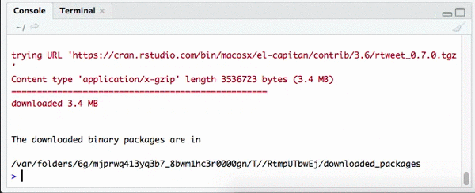

Wait until you see this blinking cursor again. It means that the installation process is complete.

## Succeed or failed?

How to tell whether the package has been successfully installed?

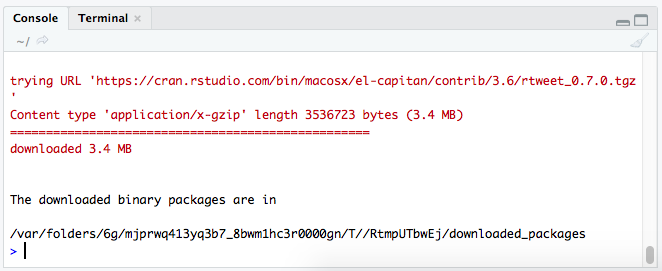

This is a typical message that you can expect if the installation is successful. The text will vary a bit, but you should be good as long as you don’t get messages like the following:

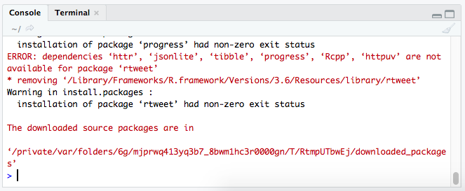

`installation of package ‘blahblah’ had non-zero exit status` indicates a failed installation. In this case, copy and paste *everything* that showed up in the console after the `install.package()` command and email me. (Don’t just send me a screenshot with only the last error message!)

## Load the package

Now that you have successfully installed the package, you have to load it in order to use its features:

```r
require("rtweet") # load the package rtweet
```

How do you know if the package has been loaded properly?

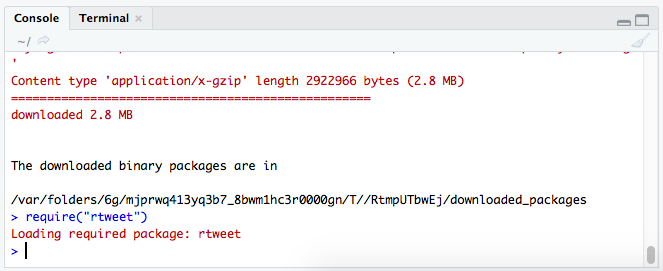

`Loading required package: blahblah` followed by a blinking cursor indicates that the package has been loaded properly.

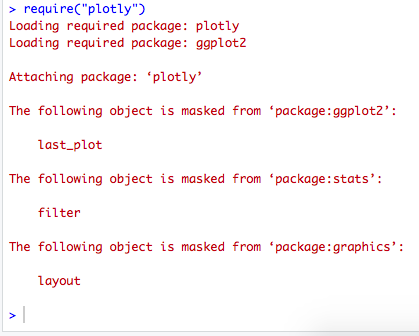

Sometimes you may also see messages like these popped up. No worries. This is also a sign of successful loading.

This happens because the package being loaded contains functions with the same name as functions in other packages that have already been loaded. Thus, R automatically masks (temporarily disables) the functions with duplicated names to avoid conflicts.

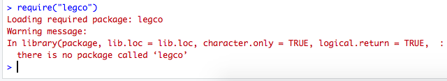

This warning message indicates that the package has not been installed. You need to repeat the steps above to ensure that the package has been successfully installed before loading it.